# Diversity begets diversity: host expansions and the diversification of plant-feeding insects | BMC Ecology and Evolution | Full Text

[Full size table](https://bmcecolevol.biomedcentral.com/articles/10.1186/1471-2148-6-4/tables/1)

[Full size table](https://bmcecolevol.biomedcentral.com/articles/10.1186/1471-2148-6-4/tables/2)

We have previously shown that diverse host plant use within the tribe Nymphalini was typically caused by ancestral polyphagy, which may or may not have secondarily evolved into more specialized interactions [12]. Virtually all documented host plant colonizations in that study led to host expansions, not to direct host shifts, and the evolutionary trend in this group was actually towards increased generalization rather than specialization. These butterflies appears to have been caught in a phase where a lowered host specificity allowed them to experiment with novel hosts, and to repeatedly reshuffle a common set of host plants, the building blocks of the host range. It appears likely that most lineages of plant-feeding insects pass through such phases of "evolutionary tinkering", where host use is expanded and diversified [c.f. [46, 47]]. Indeed, in order to complete a host shift, a species must pass through a phase of expanded host range, where both the ancestral and novel plants are used. The length of this phase will vary, depending on selection pressure and ecological setting. There are examples where fitness on the ancestral host has decreased substantially over ecological time scales [37], but on the other hand, there is evidence that ancestral hosts can linger in the repertoire for several tens of millions of years [12, 42].

Even if specialization is a pervasive pattern, the process is not irreversible and occasional episodes of host expansions could conceivably generate the necessary variation in host use to drive speciation. Expansions during shifts to novel hosts are also well documented on an ecological level [37, 48, 49]. The importance of such host expansions has probably been neglected because these phases are evolutionarily short-lived and will tend to evolve into more specialized interactions again over time [12, 24], but despite their ephemeral nature they may play a key role in the diversification of plant-feeding insects.

Even if the actual "polyphagy event" may be lost in history due to secondary specialization, the combined present range of hosts within a taxon should be a relatively accurate reflection of the ancestral host range. Hence, even if polyphagy is a trait that is difficult to trace on a phylogeny in itself [12, 17, 27], we propose that diverse host use within a taxon is a good indication of historical widening of the host plant range. It may be impossible to reconstruct which plant taxa were actual hosts at a given node in the phylogeny, but it is a fair assumption that an insect group using more plant taxa in total also has an evolutionary history involving more colonizations and hence more episodes with wider host plant ranges.

The most likely mechanism by which host expansions can increase the likelihood of speciation is that they allow the insect to gain a wider geographic distribution [50] and thus put it in a situation where genetic fragmentation is more likely. Obviously, geographic range expansions can also be caused by colonization of a single plant taxon with widespread distribution, such as the grasses, but on average the potential geographical range should expand when the host range increases.

Specialization can then promote genetic differentiation among populations either by assortative mating [10] or by increasing geographic fragmentation by allopatry [11]. Thus, plant-feeding insects may have reached their impressive species numbers not by a steady process of specialization and cospeciation, but by dynamic oscillations of host range.

This is a scenario that resembles the old biogeographical concepts of "taxon cycling" [52] or "taxon pulses" [53, 54], where pulses of speciation are mediated through shifts between marginal and interior (such as island and mainland) habitats. Our scenario should be compatible with these models, even though we see no need for a stable 'center of diversification' around which the distributional ranges fluctuate. At this point, there is no indication of particular geographical regions that seem to be disproportionately represented in the diversification of nymphalid butterflies, but this question is certainly worth investigating more thoroughly [c.f. [55, 56]]. Furthermore, as a wide host range often implies both behavioral and physiological plasticity, our scenario should also be compatible with the general hypothesis of diversification driven by phenotypic plasticity, as described by West-Eberhard [57].

We suggest that it is precisely because host specialization is *not* the "dead end" that it has often been interpreted as that plant-feeding insects have been able to become so species-rich. In fact, it is quite possible that the same applies to other diverse and often highly specialized groups, such as parasitoids and parasites. In the light of this, there is a need to direct more attention to the circumstances that can reverse the otherwise quite pervasive drive towards specialization seen in these groups.

## Conclusion

We show that diversity in host use within clades is a good predictor of species richness. As colonizations of novel plants are typically associated with host expansions such diversity is likely to have been caused by historical polyphagy [12]. Hence, we propose that much of the diversification of plant-feeding insects is driven by oscillations in host plant range, where host expansions allow the species to increase its geographical distribution and thereby setting the stage for subsequent population fragmentation by secondary specialization on different hosts in the repertoire. This latter stage can either be accomplished by allopatric isolation through increased geographic fragmentation [11] or by assortative mating [10].

## Methods

### Phylogeny

A comprehensive phylogenetic analysis of all 548 genera belonging to Nymphalidae has yet to be published. However, the relationships of various subgroups in Nymphalidae have been studied by a number of people using diverse methodology, including morphological and molecular data. The phylogeny used in this study was compiled from various sources and represents our current understanding of the phylogeny of 309 genera of Nymphalidae, not including the subfamily Satyrinae (Fig. 4). The subfamily Satyrinae contains 239 genera and about 1/3 of all nymphalid species, but was treated as a single terminal taxon in this study, as it shows little variation in host use. It is not possible at this point in time to construct a supermatrix for analysis, as the datasets used by various people are largely non-overlapping in both characters and taxa. A supertree approach is not advisable based on recent work [58]. Thus we constructed the tree for Nymphalidae by taking the relationships of various clades directly from studies that focused on those particular relationships, as detailed below. The tree in Fig. 4 represents our current best estimate of Nymphalidae phylogeny, and all sister groups in our analyses are well-supported in the original publications dealing with their relationships.

**Figure 4**

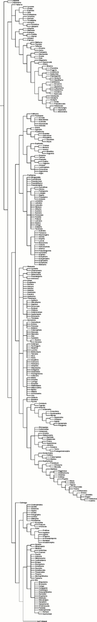

**Phylogeny of the Nymphalidae**. The phylogeny was compiled from several sources, using both molecular and morphological data (see Material and Methods for further information on the phylogenetic reconstruction and the sources used). It is resolved to the genus level, with the exception for the subfamily Satyrinae, which, due to little variation in host use, were counted as one contrast in the analysis.

[Full size image](https://bmcecolevol.biomedcentral.com/articles/10.1186/1471-2148-6-4/figures/4)

Uncertainties in relationships are shown as polytomies in Fig. 4. The deeper nodes of the phylogeny are based on molecular data from 3 gene regions, the mitochondrial COI and the nuclear EF-1α and wingless, for a total of 2929 bp [59]. The study by Wahlberg et al. [59] identified 4 major clades in Nymphalidae: the danaine clade which includes the subfamily Danainae; the satyrine clade including Calinaginae, Charaxinae, Satyrinae and Morphinae; the heliconiiine clade including Heliconiinae and Limenitidinae; and the nymphaline clade including Nymphalinae, Cyrestinae, Biblidinae and Apaturinae. These major clades are also recovered in a broader study on butterflies and skippers [60], which also shows that the libytheines belong in the family Nymphalidae. Relationships of species in the subfamily Libytheinae have been studied using morphological data showing that the genera *Libythea* and *Libytheana* are monophyletic and each others sister groups [61].

Relationships with Danainae have been extensively studied using both morphological and molecular data. Species in the tribe Danaini (the milkweed butterflies) are the subject of a book [62] in which detailed morphological data were cladistically analyzed. All genera were found to form monophyletic entities. Relationships within the species rich tribe Ithomiini have been studied using morphological [63] and molecular [64] data. The molecular analysis was based on the same genes mentioned above.

Relationships within the satyrine clade have been poorly studied, even though the clade contains the most species in Nymphalidae. The relationships of *Morpho* and related genera are taken from a morphological study [65] and a molecular study based on one gene, wingless [66]. The position of *Bia* as sister to the rest of Brassolini is suggested by a morphological study [67] and is being confirmed by a molecular study based on COI, EF-1α and wingless genes [68]. The genera *Charaxes* and *Polyura* have always been considered to be related to each other [69] and this relationship is being confirmed with molecular data from the three genes mentioned previously (N. Wahlberg, unpublished data).

Relationships within the heliconiine clade have been much studied, especially in the subfamily Heliconiinae. These studies are based on both morphological [70–72] and molecular [73, 74] data, and one study [75] combined both kinds of data.

Relationships in Limenitidinae have been less studied [76], and thus the phylogeny in Fig. 4 is largely unresolved for the subfamily. The sister relationship of *Harma* and *Cymothoe* is considered to be clear [77, 78] and is being confirmed by molecular data from COI, EF-1α and wingless (N. Wahlberg, unpublished).

Relationships in the nymphaline clade are being cleared up presently. A very recent study on the subfamily Nymphalinae based on molecular data from COI, EF-1α and wingless [79] has resolved the phylogenetic relationships of almost all genera (hence the strong representation of this subfamily in the current study). Detailed studies on several subgroups within Nymphalinae have also been used in Fig. 4, the tribe Nymphalini was studied using a combined morphological and molecular dataset with four genes [80]. The other subfamilies in the nymphaline clade have not been studied in detail. The sister relationship of *Cyrestis* and *Chersonesia* was established in a morphological study [81] and is being confirmed by molecular data [79]. A few studies have used morphological data in the subfamily Biblidinae to look at relationships at the species level [82, 83].

### Data collection

Data on host plant associations were collected from various literature sources on the level of plant family and order [62, 67, 77, 78, 84–101], following the nomenclature of the Angiosperm Phylogeny Group [102]. An index of host diversity was created by multiplying the number of plant families with the number of plant orders used by each butterfly genus. This allowed us to take variation into account on two levels of resolution, i.e. a butterfly genus utilizing two families in the same order will have a lower host diversity than a butterfly utilizing two families from two different orders. Butterfly species numbers were taken from various sources as detailed in Wahlberg [103]. We were able to find data on host plant use as well as species numbers for 292 genera in the family Nymphalidae. While butterflies are unparalleled among insects in terms of availability of host plant data, much due to the great general interest this group holds by amateur collectors as well as the general public, there are sometimes problems with the reliability of the data. The level of detail in host records vary substantially, which makes it difficult to use more fine-grained measures of host range than plant families. The largest problem is probably that anecdotal and erroneous records will tend to spread and multiply in the literature, and these can decrease the phylogenetic signal in the data [27, 84]. To limit this problem, we have followed a set of evaluation rules adopted from Janz & Nylin [27], where a host plant association was only included if it was a) reported by at least two independent sources, b) recorded from more than one species in the genus, c) if there were records of more than one plant genus from the same host plant family, or d) if the plant was the only recorded host for the genus. Because of the way that atypical information tends to gain undue attention, we believe that the risk we hereby run of erroneously excluding some data that are correct is outweighed by the advantage of excluding a greater number of records that are incorrect.

### Analyses

Data were analyzed with the MacroCAIC computer program [45], which applies the method of independent contrasts [104] to questions of species richness, as well as by reciprocal sister-group comparisons. MacroCAIC generates phylogenetically independent contrasts across the whole phylogeny. By taking all available data into account the number of contrasts found will be much higher than when manually searching for valid sister group comparisons, but by using reciprocal selection rules for sister group selection it is possible to evaluate the causal relationships behind a correlation.

Sister groups were selected using two reciprocal selection rules (Fig. 1). First, by recursively searching down the butterfly phylogeny for the first sister pair that differed in diversity of host use. At that point we stopped, excluding all nodes below it in the phylogeny (so as to ensure independent comparisons). We then continued in the same manner across the whole phylogeny until all possible independent sister groups were found (Table 1). Second, we used the same method to instead search for clades that differed in species numbers (Table 2). This reciprocity allowed us to evaluate our hypothesis against the alternative hypothesis that species rich clades are expected to have more hosts by chance alone. Valid comparisons of both types were analyzed with sign tests for finding correlated differences in host diversity and species richness. Provided that there is an overall correlation, in many (most) cases, the sister group contrasts found with the two methods will be identical. However, as long as the correlation is not perfect, there will be cases where a difference in one character is not followed by a difference in the other. If these discrepancies from a perfect correlation are disproportionately found in one of the sister group comparisons, they can provide insight into the causation behind the correlation. For example, we may find a large number of contrasts in species richness that is not associated with positive contrasts in host diversity, but few cases of the reciprocal discrepancy (where a contrast in host diversity is not associated with a positive contrast in species richness). This means that differences in species richness sometimes evolve for reasons not associated with host diversity, but when there is a difference in host diversity, it is predictably followed by an increase in species richness. Conversely, the opposite pattern would mean that host diversity often evolves without a corresponding increase in species richness, but when there are differences in species richness, it is predictably followed by an increase in host diversity. In the first case we would conclude that, even though host diversity cannot be the only factor that influences patterns of species richness, when we do have an increase in host diversity, it seems to trigger an increase in species richness. In the second case we would conclude that, even though species richness cannot be the only factor that influences patterns of host diversity, when we do have an increase in species richness, it seems to trigger an increase in host diversity.

## References

1. May RM: How many species?. Phil Tran R Soc Lond B. 1990, 330: 293-304.

   [Google Scholar](http://scholar.google.com/scholar_lookup?&title=How%20many%20species%3F&journal=Phil%20Tran%20R%20Soc%20Lond%20B&volume=330&pages=293-304&publication_year=1990&author=May%2CRM)
2. Wilson EO: The diversity of life. 1992, Cambridge, Massachusetts: Harvard University Press

   [Google Scholar](http://scholar.google.com/scholar_lookup?&title=The%20diversity%20of%20life&publication_year=1992&author=Wilson%2CEO)
3. Ehrlich PR, Raven PH: Butterflies and plants: a study in coevolution. Evolution. 1964, 18: 586-608.

   Google Scholar
4. Mitter C, Farrell B, Weigmann B: The phylogenetic study of adaptive zones: has phytophagy promoted insect diversification?. Am Nat. 1988, 132: 107-128. 10.1086/284840.

   Google Scholar
5. Farrell BD: "Inordinate fondness" explained: Why are there so many beetles?. Science. 1998, 281: 555-559. 10.1126/science.281.5376.555.

   [CAS](https://bmcecolevol.biomedcentral.com/articles/cas-redirect/1:CAS:528:DyaK1cXkvFCrs7k%3D) [PubMed](http://www.ncbi.nlm.nih.gov/entrez/query.fcgi?cmd=Retrieve&db=PubMed&dopt=Abstract&list_uids=9677197) Google Scholar
6. Schluter D: The Ecology of Adaptive Radiation. 2000, Oxford: Oxford University Press

   [Google Scholar](http://scholar.google.com/scholar_lookup?&title=The%20Ecology%20of%20Adaptive%20Radiation&publication_year=2000&author=Schluter%2CD)
7. Jaenike J: Host specialization in phytophagous insects. Annu Rev Ecol Syst. 1990, 21: 243-273. 10.1146/annurev.es.21.110190.001331.

   Google Scholar
8. Futuyma DJ: Evolution of host specificity in herbivorous insects: genetic, ecological, and phylogenetic aspects. Plant-Animal Interactions: Evolutionary Ecology in Tropical and Temperate Regions. Edited by: Price PW, Lewinsohn TM, Fernandes GW, Benson WW. 1991, New York: John Wiley & Sons, 431-454.

   Google Scholar
9. Thompson JN: The coevolutionary process. 1994, Chicago: University of Chicago Press

   [Google Scholar](http://scholar.google.com/scholar_lookup?&title=The%20coevolutionary%20process&publication_year=1994&author=Thompson%2CJN)
10. Hawthorne DJ, Via S: Genetic linkage of ecological specialization and reproductive isolation in pea aphids. Nature. 2001, 412: 904-907. 10.1038/35091062.

    [CAS](https://bmcecolevol.biomedcentral.com/articles/cas-redirect/1:STN:280:DC%2BD3Mvos1Witw%3D%3D) [PubMed](http://www.ncbi.nlm.nih.gov/entrez/query.fcgi?cmd=Retrieve&db=PubMed&dopt=Abstract&list_uids=11528477) Google Scholar
11. Kelley ST, Farrell BD, Mitton JB: Effects of specialization on genetic differentiation in sister species of bark beetles. Heredity. 2000, 84: 218-227. 10.1046/j.1365-2540.2000.00662.x.

    [PubMed](http://www.ncbi.nlm.nih.gov/entrez/query.fcgi?cmd=Retrieve&db=PubMed&dopt=Abstract&list_uids=10762392) Google Scholar
12. Janz N, Nylin S, Nyblom K: Evolutionary dynamics of host plant specialization: a case study of the tribe Nymphalini. Evolution. 2001, 55: 783-796.

    [CAS](https://bmcecolevol.biomedcentral.com/articles/cas-redirect/1:STN:280:DC%2BD3MzhvVSksQ%3D%3D) [PubMed](http://www.ncbi.nlm.nih.gov/entrez/query.fcgi?cmd=Retrieve&db=PubMed&dopt=Abstract&list_uids=11392396) Google Scholar
13. Bush GL: Sympatric speciation in phytophagous parasitic insects. Evolutionary Strategies of Parasitic Insects and Mites. Edited by: Price PW. 1975, London: Plenum, 187-206.

    [Google Scholar](http://scholar.google.com/scholar_lookup?&title=Sympatric%20speciation%20in%20phytophagous%20parasitic%20insects&pages=187-206&publication_year=1975&author=Bush%2CGL)
14. Carroll SP, Boyd C: Host race formation in the soapberry bug: natural history with the history. Evolution. 1992, 46: 1052-1069.

    Google Scholar
15. Feder JL, Chilcote CA, Bush GL: Genetic differentiation between sympatric host races of the apple maggot fly *Rhagoletis pomonella*. Nature. 1988, 336: 61-64. 10.1038/336061a0.

    Google Scholar
16. Peterson MA, Denno RF: The influence of dispersal and diet breadth on patterns of genetic isolation by distance in phytophagous insects. Am Nat. 1998, 152: 428-446. 10.1086/286180.

    [CAS](https://bmcecolevol.biomedcentral.com/articles/cas-redirect/1:STN:280:DC%2BD1cnit12hug%3D%3D) [PubMed](http://www.ncbi.nlm.nih.gov/entrez/query.fcgi?cmd=Retrieve&db=PubMed&dopt=Abstract&list_uids=18811450) Google Scholar
17. Stireman JO: The evolution of generalization? Parasitoid flies and the perils of inferring host range evolution from phylogenies. J Evol Biol. 2005, 18: 325-336. 10.1111/j.1420-9101.2004.00850.x.

    [PubMed](http://www.ncbi.nlm.nih.gov/entrez/query.fcgi?cmd=Retrieve&db=PubMed&dopt=Abstract&list_uids=15715839) Google Scholar
18. Brooks DR, McLennan DA: The nature of diversity: an evolutionary voyage of discovery. 2002, Chicago: University of Chicago Press

    [Google Scholar](http://scholar.google.com/scholar_lookup?&title=The%20nature%20of%20diversity%3A%20an%20evolutionary%20voyage%20of%20discovery&publication_year=2002&author=Brooks%2CDR&author=McLennan%2CDA)
19. Janz N, Thompson JN: Plant polyploidy and host expansion in an insect herbivore. Oecologia. 2002, 130: 570-575. 10.1007/s00442-001-0832-1.

    Google Scholar
20. Thompson JN, Cunningham BM, Segraves KA, Althoff DM, Wagner D: Plant polyploidy and insect/plant interactions. Am Nat. 1997, 150: 730-743. 10.1086/286091.

    [CAS](https://bmcecolevol.biomedcentral.com/articles/cas-redirect/1:STN:280:DC%2BD1cnit1yisQ%3D%3D) [PubMed](http://www.ncbi.nlm.nih.gov/entrez/query.fcgi?cmd=Retrieve&db=PubMed&dopt=Abstract&list_uids=18811333) Google Scholar
21. Pellmyr O, Leebens-Mack J: Reversal of mutualism as a mechanism for adaptive radiation in yucca moths. Am Nat. 2000, 156: S62-S76. 10.1086/303416.

    Google Scholar
22. Poulin R: Relative infection levels and taxonomic distances among the host species used by a parasite: insights into parasite specialization. Parasitology. 2005, 130: 109-115. 10.1017/S0031182004006304.

    [CAS](https://bmcecolevol.biomedcentral.com/articles/cas-redirect/1:STN:280:DC%2BD2M%2FntFGltA%3D%3D) [PubMed](http://www.ncbi.nlm.nih.gov/entrez/query.fcgi?cmd=Retrieve&db=PubMed&dopt=Abstract&list_uids=15700762) Google Scholar
23. Radtke A, McLennan DA, Brooks DR: Resource tracking in North American *Telorchis* spr (Digenea : Plagiorchiformes : Telorchidae). J Parasitol. 2002, 88: 874-879.

    [PubMed](http://www.ncbi.nlm.nih.gov/entrez/query.fcgi?cmd=Retrieve&db=PubMed&dopt=Abstract&list_uids=12435123) Google Scholar
24. Nosil P: Transition rates between specialization and generalization in phytophagous insects. Evolution. 2002, 56: 1701-1706.

    [CAS](https://bmcecolevol.biomedcentral.com/articles/cas-redirect/1:STN:280:DC%2BD38vpt1CqsA%3D%3D) [PubMed](http://www.ncbi.nlm.nih.gov/entrez/query.fcgi?cmd=Retrieve&db=PubMed&dopt=Abstract&list_uids=12353763) Google Scholar
25. Anderson RS: Weevils and plants – phylogenetic versus ecological mediation of evolution of host plant associations in Curculioninae (Coleoptera, Curculionidae). Mem Entomol Soc Can. 1993, 165: 197-232.

    Google Scholar
26. Dobler S, Mardulyn P, Pasteels JM, Rowell-Rahier M: Host-plant switches and the evolution of chemical defense and life history in the leaf beetle genus *Oreina*. Evolution. 1996, 50: 2373-2386.

    Google Scholar
27. Janz N, Nylin S: Butterflies and plants: a phylogenetic study. Evolution. 1998, 52: 486-502.

    [Google Scholar](http://scholar.google.com/scholar_lookup?&title=Butterflies%20and%20plants%3A%20a%20phylogenetic%20study&journal=Evolution&volume=52&pages=486-502&publication_year=1998&author=Janz%2CN&author=Nylin%2CS)
28. Lopez-Vaamonde C, Charles H, Godfray J, Cook JM: Evolutionary dynamics of host-plant use in a genus of leaf-mining moths. Evolution. 2003, 57: 1804-1821.

    [PubMed](http://www.ncbi.nlm.nih.gov/entrez/query.fcgi?cmd=Retrieve&db=PubMed&dopt=Abstract&list_uids=14503622) Google Scholar
29. Pellmyr O: Yuccas, yucca moths and coevolution: a review. Ann Mo Bot Gard. 2003, 90: 35-55.

    [Google Scholar](http://scholar.google.com/scholar_lookup?&title=Yuccas%2C%20yucca%20moths%20and%20coevolution%3A%20a%20review&journal=Ann%20Mo%20Bot%20Gard&volume=90&pages=35-55&publication_year=2003&author=Pellmyr%2CO)
30. Percy DM, Page RDM, Cronk QCB: Plant-insect interactions: double-dating associated insect and plant lineages reveals asynchronous radiations. Syst Biol. 2004, 53: 120-127. 10.1080/10635150490264996.

    [PubMed](http://www.ncbi.nlm.nih.gov/entrez/query.fcgi?cmd=Retrieve&db=PubMed&dopt=Abstract&list_uids=14965907) Google Scholar
31. Ronquist F, Liljeblad J: Evolution of the gall wasp-host plant association. Evolution. 2001, 55: 2503-2522.

    [CAS](https://bmcecolevol.biomedcentral.com/articles/cas-redirect/1:STN:280:DC%2BD387gtVOmtA%3D%3D) [PubMed](http://www.ncbi.nlm.nih.gov/entrez/query.fcgi?cmd=Retrieve&db=PubMed&dopt=Abstract&list_uids=11831666) Google Scholar
32. Roy BA: Patterns of association between crucifers and their flower- mimic pathogens: host jumps are more common than coevolution or cospeciation. Evolution. 2001, 55: 41-53.

    [CAS](https://bmcecolevol.biomedcentral.com/articles/cas-redirect/1:STN:280:DC%2BD3M7mt1Glsg%3D%3D) [PubMed](http://www.ncbi.nlm.nih.gov/entrez/query.fcgi?cmd=Retrieve&db=PubMed&dopt=Abstract&list_uids=11263745) Google Scholar
33. Weintraub JD, Lawton JH, Scoble MJ: Lithinine moths on ferns: A phylogenetic study of insect-plant interactions. Biol J Linn Soc. 1995, 55: 239-250. 10.1006/bijl.1995.0039.

    Google Scholar
34. Nyman T: The willow bud galler *Euura mucronata* Hartig (Hymenoptera : Tenthredinidae): one polyphage or many monophages?. Heredity. 2002, 88: 288-295. 10.1038/sj.hdy.6800042.

    [CAS](https://bmcecolevol.biomedcentral.com/articles/cas-redirect/1:STN:280:DC%2BD387oslGrug%3D%3D) [PubMed](http://www.ncbi.nlm.nih.gov/entrez/query.fcgi?cmd=Retrieve&db=PubMed&dopt=Abstract&list_uids=11920137) Google Scholar
35. Thompson JN: The geographic mosaic of coevolution. 2005, Chicago: University Of Chicago Press

    [Google Scholar](http://scholar.google.com/scholar_lookup?&title=The%20geographic%20mosaic%20of%20coevolution&publication_year=2005&author=Thompson%2CJN)
36. Tabashnik BE: Host range evolution: the shift from native legume hosts to alfalfa by the butterfly, *Colias philodice eriphyle*. Evolution. 1983, 37: 150-162.

    Google Scholar
37. Singer MC, Thomas CD, Parmesan C: Rapid human-induced evolution of insect-host associations. Nature. 1993, 366: 681-683. 10.1038/366681a0.

    Google Scholar
38. Thomas CD, Ng D, Singer MC, Mallet JLB, Parmesan C, Billington HL: Incorporation of a European weed into the diet of a North American herbivore. Evolution. 1987, 41: 892-901.

    Google Scholar
39. Fox CW, Nilsson JA, Mousseau TA: The ecology of diet expansion in a seed-feeding beetle: Pre-existing variation, rapid adaptation and maternal effects?. Evol Ecol. 1997, 11: 183-194. 10.1023/A:1018499832664.

    Google Scholar
40. Futuyma DJ, Keese MC, Scheffer SJ: Genetic constraints and the phylogeny of insect-plant associations – responses of *Ophraella communa* (Coleoptera, Chrysomelidae) to host plants of its congeners. Evolution. 1993, 47: 888-905.

    Google Scholar
41. Futuyma DJ, Walsh JS, Morton T, Funk DJ, Keese MC: Genetic variation in a phylogenetic context – responses of 2 specialized leaf beetles (Coleoptera, Chrysomelidae) to host plants of their congeners. J Evol Biol. 1994, 7: 127-146. 10.1046/j.1420-9101.1994.7020127.x.

    Google Scholar
42. Futuyma DJ, Keese MC, Funk DJ: Genetic constraints on macroevolution: the evolution of host affiliation in the leaf beetle genus *Ophraella*. Evolution. 1995, 49: 797-809.

    Google Scholar
43. Funk DJ, Futuyma DJ, Ortí G, Meyer A: A history of host associations and evolutionary diversification for *Ophraella* (Coleoptera: Chrysomelidae): new evidence from mitochondrial DNA. Evolution. 1995, 49: 1008-1017.

    [CAS](https://bmcecolevol.biomedcentral.com/articles/cas-redirect/1:CAS:528:DyaK28Xktlyitg%3D%3D) Google Scholar
44. Weingartner E, Wahlberg N, Nylin S: Dynamics of host plant use and species diversity in *Polygonia* butterflies (Nymphalidae). J Evol Biol. 2005, doi:10.1111/j.1420-9101.2005.01009.x:,

    Google Scholar
45. Agapow PM, Isaac NJB: MacroCAIC: revealing correlates of species richness by comparative analysis. Divers Distrib. 2002, 8: 41-43. 10.1046/j.1366-9516.2001.00121.x.

    Google Scholar
46. Armbruster WS, Baldwin BG: Switch from specialized to generalized pollination. Nature. 1998, 394: 632-632. 10.1038/29210.

    [CAS](https://bmcecolevol.biomedcentral.com/articles/cas-redirect/1:CAS:528:DyaK1cXlsFKhs7k%3D) Google Scholar
47. Scheffer SJ, Wiegmann BM: Molecular phylogenetics of the holly leaf miners (Diptera : Agromyzidae : Phytomyza): Species limits, speciation, and dietary specialization. Mol Phyl Evol. 2000, 17: 244-255. 10.1006/mpev.2000.0830.

    [CAS](https://bmcecolevol.biomedcentral.com/articles/cas-redirect/1:CAS:528:DC%2BD3cXotFWgtrY%3D) Google Scholar
48. Camara MD: A recent host range expansion in *Junonia coenia* Hubner (Nymphalidae): Oviposition preference, survival, growth, and chemical defense. Evolution. 1997, 51: 873-884.

    Google Scholar
49. Fraser SM, Lawton JH: Host range expansion by British moths onto introduced conifers. Ecol Entomol. 1994, 19: 127-137.

    Google Scholar
50. Päivinen J, Grapputo A, Kaitala V, Komonen A, Kotiaho JS, Saarinen K, Wahlberg N: Negative density-distribution relationship in butterflies. BMC Biol. 2005, 3: 5-10.1186/1741-7007-3-5.

    [PubMed Central](http://www.ncbi.nlm.nih.gov/pmc/articles/PMC554103) [PubMed](http://www.ncbi.nlm.nih.gov/entrez/query.fcgi?cmd=Retrieve&db=PubMed&dopt=Abstract&list_uids=15737240) Google Scholar
51. Fox LR, Morrow PA: Specialization: species property or local phenomenon?. Science. 1981, 211: 887-893.

    [CAS](https://bmcecolevol.biomedcentral.com/articles/cas-redirect/1:STN:280:DC%2BC3cvktl2jsA%3D%3D) [PubMed](http://www.ncbi.nlm.nih.gov/entrez/query.fcgi?cmd=Retrieve&db=PubMed&dopt=Abstract&list_uids=17819016) Google Scholar
52. Wilson EO: The nature of the taxon cycle in the Melanesian ant fauna. Am Nat. 1961, 95: 169-193. 10.1086/282174.

    Google Scholar
53. Erwin TL: Taxon pulses, vicariance, and dispersal: an evolutionary synthesis illustrated by carabid beetles. Vicariance biogeography – a critique. Edited by: Nelson G, Rosen DE. 1981, New York: Columbia University Press, 159-196.

    Google Scholar
54. Erwin TL: The taxon pulse: a general pattern of lineage radiation and extinction among carabid beetles. Taxonomy, phylogeny, and zoogeography of beetles and ants. Edited by: Ball GE. 1985, Dordrecht: W. Junk, 437-472.

    Google Scholar
55. Halas D, Zamparo D, Brooks DR: A historical biogeographical protocol for studying biotic diversification by taxon pulses. J Biogeogr. 2005, 32: 249-260. 10.1111/j.1365-2699.2004.01147.x.

    Google Scholar
56. Spironello M, Brooks DR: Dispersal and diversification: macroevolutionary implications of the MacArthur-Wilson model, illustrated by *Simulium* (*Inseliellum*) Rubstov (Diptera: Simuliidae). J Biogeogr. 2003, 30: 1563-1573. 10.1046/j.1365-2699.2003.00945.x.

    Google Scholar
57. West-Eberhard MJ: Developmental plasticity and evolution. 2003, New York: Oxford University Press

    [Google Scholar](http://scholar.google.com/scholar_lookup?&title=Developmental%20plasticity%20and%20evolution&publication_year=2003&author=West-Eberhard%2CMJ)
58. Gatesy J, Baker RH, Hayashi C: Inconsistencies in arguments for the supertree approach: supermatrices versus supertrees of Crocodylia. Syst Biol. 2004, 53: 342-355. 10.1080/10635150490423971.

    [PubMed](http://www.ncbi.nlm.nih.gov/entrez/query.fcgi?cmd=Retrieve&db=PubMed&dopt=Abstract&list_uids=15205058) Google Scholar
59. Wahlberg N, Weingartner E, Nylin S: Towards a better understanding of the higher systematics of Nymphalidae (Lepidoptera : Papilionoidea). Mol Phyl Evol. 2003, 28: 473-484. 10.1016/S1055-7903(03)00052-6.

    [CAS](https://bmcecolevol.biomedcentral.com/articles/cas-redirect/1:CAS:528:DC%2BD3sXmt1egsbg%3D) Google Scholar
60. Wahlberg N, Braby MF, Brower AVZ, de Jong R, Lee MM, Nylin S, Pierce NE, Sperling FAH, Vila R, Warren AD, Zakharov E: Synergistic effects of combining morphological and molecular data in resolving the phylogeny of butterflies and skippers. Proc R Soc Lond B. 2005, 272: 1577-1586.

    [CAS](https://bmcecolevol.biomedcentral.com/articles/cas-redirect/1:CAS:528:DC%2BD2MXhtVersrjJ) Google Scholar
61. Kawahara AY: Rediscovery of Libythea collenettei Poulton & Riley (Nymphalidae: Libytheinae) in the Marquesas, and a description of the male. J Lep Soc. 2003, 57: 81-85.

    Google Scholar
62. Ackery PR, Vane-Wright RI: Milkweed butterflies: their cladistics and biology. 1984, London: British Museum (Natural History)

    [Google Scholar](http://scholar.google.com/scholar_lookup?&title=Milkweed%20butterflies%3A%20their%20cladistics%20and%20biology&publication_year=1984&author=Ackery%2CPR&author=Vane-Wright%2CRI)
63. Brown KSJ, Freitas AVL: Juvenile stages of Ithomiinae: overview and systematics (Lepidoptera: Nymphalidae). Tropical Lepidoptera. 1994, 5: 9-20.

    Google Scholar
64. Brower AVZ, Freitas AVL, Lee M-M, Silva Brandão KL, Whinnett A, Willmott KR: Phylogenetic relationships among the Ithomiini (Lepidoptera: Nymphalidae) inferred from one mitochondrial and two nuclear gene regions. Syst Ent. 2006,

    Google Scholar
65. Penz CM, DeVries PJ: Phylogenetic analysis of Morpho butterflies (Nymphalidae, Morphinae): implications for classification and natural history. Am Mus Novit. 2002, 3374: 1-33. 10.1206/0003-0082(2002)374<0001:PAOMBN>2.0.CO;2.

    Google Scholar
66. Brower AVZ: Phylogenetic relationships among the Nymphalidae (Lepidoptera), inferred from partial sequences of the wingless gene. Proc R Soc Lond B. 2000, 267: 1201-1211. 10.1098/rspb.2000.1129.

    [CAS](https://bmcecolevol.biomedcentral.com/articles/cas-redirect/1:CAS:528:DC%2BD3cXlsFyqtL0%3D) Google Scholar
67. Freitas AVL, Murray DAH, Brown KS: Immatures, natural history and the systematic position of Bia actorion (Nymphalidae). J Lep Soc. 2002, 56: 117-122.

    Google Scholar
68. Peña C, Wahlberg N, Weingartner E, Kodandaramaiah U, Nylin S, Freitas AVL, Brower AVZ: Higher level phylogeny of Satyrinae butterflies (Lepidoptera: Nymphalidae) based on DNA sequence data. Mol Phyl Evol.
69. Harvey DJ: Higher classification of the Nymphalidae, Appendix B. The Development and Evolution of Butterfly Wing Patterns. Edited by: Nijhout HF. 1991, Washington DC: Smithsonian Institution Press, 255-273.

    [Google Scholar](http://scholar.google.com/scholar_lookup?&title=Higher%20classification%20of%20the%20Nymphalidae%2C%20Appendix%20B&pages=255-273&publication_year=1991&author=Harvey%2CDJ)
70. Penz CM: Higher level phylogeny for the passion-vine butterflies (Nymphalidae, Heliconiinae) based on early stage and adult morphology. Zool J Linn Soc. 1999, 127: 277-344. 10.1006/zjls.1998.0187.

    Google Scholar
71. Penz CM, Peggie D: Phylogenetic relationships among Heliconiinae genera based on morphology (Lepidoptera: Nymphalidae). Syst Ent. 2003, 28: 451-479. 10.1046/j.1365-3113.2003.00221.x.

    Google Scholar
72. Pierre J: Systématique cladistique chez les *Acraea* (Lepidoptera, Nymphalidae). Ann Soc Entomol Fr. 1987, 23: 11-27.

    Google Scholar
73. Brower AVZ: Phylogeny of *Heliconius* butterflies inferred from mitochondrial DNA sequences. Mol Phyl Evol. 1994, 3: 159-174. 10.1006/mpev.1994.1018.

    [CAS](https://bmcecolevol.biomedcentral.com/articles/cas-redirect/1:CAS:528:DyaK2MXmtVertQ%3D%3D) Google Scholar
74. Brower AVZ, Egan MG: Cladistic analysis of *Heliconius* butterflies and relatives (Nymphalidae: Heliconiiti): a revised phylogenetic position for *Eueides* based on sequences from mtDNA and a nuclear gene. Proc R Soc Lond B. 1997, 264: 969-977. 10.1098/rspb.1997.0134.

    [CAS](https://bmcecolevol.biomedcentral.com/articles/cas-redirect/1:CAS:528:DyaK2sXls1Wiu74%3D) Google Scholar
75. Simonsen TJ: Fritillary butterflies: phylogeny, historical zoogeography and morphological aspects of the tribus Argynnini (Lepidoptera: Nymphalidae). PhD thesis. 2004, University of Copenhagen, Department of Entomology, Zoological Museum

    Google Scholar
76. Willmott KR: Cladistic analysis of the Neotropical butterfly genus *Adelpha* (Lepidoptera: Nymphalidae), with comments on the subtribal classification of Limenitidini. Syst Ent. 2003, 28: 279-322. 10.1046/j.1365-3113.2003.00209.x.

    Google Scholar
77. Larsen TB: The butterflies of Kenya and their natural history. 1991, Oxford: Oxford University Press

    [Google Scholar](http://scholar.google.com/scholar_lookup?&title=The%20butterflies%20of%20Kenya%20and%20their%20natural%20history&publication_year=1991&author=Larsen%2CTB)
78. Larsen TB: Butterflies of West Africa. 2005, Stenstrup, Denmark: Apollo Books

    [Google Scholar](http://scholar.google.com/scholar_lookup?&title=Butterflies%20of%20West%20Africa&publication_year=2005&author=Larsen%2CTB)
79. Wahlberg N, Brower AVZ, Nylin S: Phylogenetic relationships and historical biogeography of tribes and genera in the subfamily Nymphalinae (Lepidoptera: Nymphalidae). Biol J Linn Soc. 2005, 86: 227-251. 10.1111/j.1095-8312.2005.00531.x.

    Google Scholar
80. Wahlberg N, Nylin S: Morphology versus molecules: resolution of the positions of *Nymphalis*, *Polygonia*, and related genera (Lepidoptera : Nymphalidae). Cladistics. 2003, 19: 213-223. 10.1111/j.1096-0031.2003.tb00364.x.

    Google Scholar
81. Holloway JD: The affinities within four butterfly groups (Lepidoptera: Rhopalocera) in relation to general patterns of butterfly distribution in the Indo-Australian area. Trans R Entomol Soc. 1973, 125: 125-176.

    Google Scholar
82. Hill RI, Penz CM, DeVries PJ: Phylogenetic analysis and review of *Panacea* and *Batesia* butterflies (Nymphalidae). J Lep Soc. 2002, 56: 199-215.

    Google Scholar
83. Jenkins DW: Neotropical Nymphalidae. VIII. Revision of *Eunica*. Bulletin of the Allyn Museum. 1990, 131: 1-175.

    Google Scholar
84. Ackery PR: Host plants and classification: a review of nymphalid butterflies. Biol J Linn Soc. 1988, 33: 95-203.

    Google Scholar
85. Asher J, Warren M, Fox R, Harding P, Jeffcoate G, Jeffcoate S: The millenium atlas of butterflies in Britain and Ireland. 2001, Oxford: Oxford University Press

    Google Scholar
86. Bascombe MJ, Johnston G, Bascombe FS: The Butterflies of Hong Kong. 1999, London: Academic Press

    [Google Scholar](http://scholar.google.com/scholar_lookup?&title=The%20Butterflies%20of%20Hong%20Kong&publication_year=1999&author=Bascombe%2CMJ&author=Johnston%2CG&author=Bascombe%2CFS)
87. Carrión Cabrera JE: Estatus de *Atlantea tulita* (Dewitz, 1877) en Puerto Rico. Masters thesis. 2003, Universidad de Puerto Rico, Departamento de Biología, Universidad de Puerto Rico

    [Google Scholar](http://scholar.google.com/scholar_lookup?&title=Estatus%20de%20Atlantea%20tulita%20%28Dewitz%2C%201877%29%20en%20Puerto%20Rico&publication_year=2003&author=Carri%C3%B3n%20Cabrera%2CJE)
88. Common IFB, Waterhouse DF: Butterflies of Australia. 1972, Sydney: Angus and Robertson

    [Google Scholar](http://scholar.google.com/scholar_lookup?&title=Butterflies%20of%20Australia&publication_year=1972&author=Common%2CIFB&author=Waterhouse%2CDF)
89. Corbet AS, Pendlebury HM: The butterflies of the Malay Peninsula. 1992, Kuala Lumpur: Malayan Nature Society

    [Google Scholar](http://scholar.google.com/scholar_lookup?&title=The%20butterflies%20of%20the%20Malay%20Peninsula&publication_year=1992&author=Corbet%2CAS&author=Pendlebury%2CHM)
90. DeVries PJ: The butterflies of Costa Rica and their natural history, Papilionidae, Pieridae, Nymphalidae. 1987, Princeton: Princeton University Press

    Google Scholar
91. Ebert G: Die Schmetterlinge Baden-Württembergs. 1993, Stuttgart: Verlag Eugen Ulmer

    [Google Scholar](http://scholar.google.com/scholar_lookup?&title=Die%20Schmetterlinge%20Baden-W%C3%BCrttembergs&publication_year=1993&author=Ebert%2CG)
92. Gibbs GW: New Zealand Butterflies: Identification and Natural History. 1980, Auckland: William Collins Publishers Ltd

    [Google Scholar](http://scholar.google.com/scholar_lookup?&title=New%20Zealand%20Butterflies%3A%20Identification%20and%20Natural%20History&publication_year=1980&author=Gibbs%2CGW)
93. Johnston G, Johnston B: This is Hong Kong: Butterflies. 1980, Hong Kong: Hong Kong Government Publications

    [Google Scholar](http://scholar.google.com/scholar_lookup?&title=This%20is%20Hong%20Kong%3A%20Butterflies&publication_year=1980&author=Johnston%2CG&author=Johnston%2CB)
94. Larsen TB: Butterflies of Lebanon. 1974, Beirut: National Council for Scientific Research

    [Google Scholar](http://scholar.google.com/scholar_lookup?&title=Butterflies%20of%20Lebanon&publication_year=1974&author=Larsen%2CTB)
95. Parsons M: Butterflies of the Bulolo-Wau valley. 1991, Honolulu: Bishop Museum Press

    [Google Scholar](http://scholar.google.com/scholar_lookup?&title=Butterflies%20of%20the%20Bulolo-Wau%20valley&publication_year=1991&author=Parsons%2CM)
96. Pyle RM: The Audobon Society Field Guide to North American Butterflies. 1981, New York: Alfred A. Knopf

    [Google Scholar](http://scholar.google.com/scholar_lookup?&title=The%20Audobon%20Society%20Field%20Guide%20to%20North%20American%20Butterflies&publication_year=1981&author=Pyle%2CRM)
97. Lepidoptera and some other life-forms. [http://www.funet.fi/pub/sci/bio/life/intro.html]
98. Scott JA: The butterflies of North America. 1986, Stanford, CA: Stanford University Press

    [Google Scholar](http://scholar.google.com/scholar_lookup?&title=The%20butterflies%20of%20North%20America&publication_year=1986&author=Scott%2CJA)
99. Smart P: The illustrated encyclopedia of the butterfly world. 1975, London: Salamander Books

    [Google Scholar](http://scholar.google.com/scholar_lookup?&title=The%20illustrated%20encyclopedia%20of%20the%20butterfly%20world&publication_year=1975&author=Smart%2CP)
100. Tolman T: Butterflies of Europe. 1997, Princeton and Oxford: Princeton University Press

     [Google Scholar](http://scholar.google.com/scholar_lookup?&title=Butterflies%20of%20Europe&publication_year=1997&author=Tolman%2CT)
101. Tuzov VK: Guide to the butterflies of Russia and adjacent territories. 2000, Sofia: Pensoft

     [Google Scholar](http://scholar.google.com/scholar_lookup?&title=Guide%20to%20the%20butterflies%20of%20Russia%20and%20adjacent%20territories&publication_year=2000&author=Tuzov%2CVK)
102. Bremer B, Bremer K, Chase MW, Reveal JL, Soltis DE, Soltis PS, Stevens PF, Anderberg AA, Fay MF, Goldblatt P, Judd WS, Kallersjo M, Karehed J, Kron KA, Lundberg J, Nickrent DL, Olmstead RG, Oxelman B, Pires JC, Rodman JE, Rudall PJ, Savolainen V, Sytsma KJ, van der Bank M, Wurdack K, Xiang JQY, Zmarzty S: An update of the Angiosperm Phylogeny Group classification for the orders and families of flowering plants: APG II. Bot J Linn Soc. 2003, 141: 399-436. 10.1046/j.1095-8339.2003.t01-1-00158.x.

     Google Scholar
103. The classification of Nymphalidae. [http://www.zoologi.su.se/research/wahlberg/Nymphalidae/Classification2.htm]
104. Felsenstein J: Phylogenies and the comparative method. Am Nat. 1985, 125: 1-15. 10.1086/284325.

     [Google Scholar](http://scholar.google.com/scholar_lookup?&title=Phylogenies%20and%20the%20comparative%20method&journal=Am%20Nat&doi=10.1086%2F284325&volume=125&pages=1-15&publication_year=1985&author=Felsenstein%2CJ)

[Download references](https://citation-needed.springer.com/v2/references/10.1186/1471-2148-6-4?format=refman&flavour=references)

## Acknowledgements

We wish to thank four anonymous reviewers for their critical comments that helped to significantly improve the manuscript. This work was supported by grants from the Swedish Research Council to NJ, SN and NW.

## Author information

### Authors and Affiliations

1. Department of Zoology, Stockholm University, 106 91, Stockholm, Sweden

   Niklas Janz, Sören Nylin & Niklas Wahlberg

### Corresponding author

Correspondence to Niklas Janz.

## Additional information

### Authors' contributions

NJ and SN conceived of the study and made preliminary analyses, NJ collected the data, carried out final analyses and wrote the paper, NW performed the phylogenetic reconstructions and wrote part of the methods. All authors partook in discussions during analysis and writing, read and approved the final manuscript.

## Authors’ original submitted files for images

Below are the links to the authors’ original submitted files for images.

### [Authors’ original file for figure 1](https://static-content.springer.com/esm/art%3A10.1186%2F1471-2148-6-4/MediaObjects/12862_2005_189_MOESM1_ESM.pdf)

### [Authors’ original file for figure 2](https://static-content.springer.com/esm/art%3A10.1186%2F1471-2148-6-4/MediaObjects/12862_2005_189_MOESM2_ESM.pdf)

### [Authors’ original file for figure 3](https://static-content.springer.com/esm/art%3A10.1186%2F1471-2148-6-4/MediaObjects/12862_2005_189_MOESM3_ESM.pdf)

### [Authors’ original file for figure 4](https://static-content.springer.com/esm/art%3A10.1186%2F1471-2148-6-4/MediaObjects/12862_2005_189_MOESM4_ESM.pdf)

## Rights and permissions

**Open Access** This article is published under license to BioMed Central Ltd. This is an Open Access article is distributed under the terms of the Creative Commons Attribution License ( https://creativecommons.org/licenses/by/2.0 ), which permits unrestricted use, distribution, and reproduction in any medium, provided the original work is properly cited.

Reprints and Permissions

## About this article

### Cite this article

Janz, N., Nylin, S. & Wahlberg, N. Diversity begets diversity: host expansions and the diversification of plant-feeding insects. *BMC Evol Biol* **6**, 4 (2006). https://doi.org/10.1186/1471-2148-6-4

[Download citation](https://citation-needed.springer.com/v2/references/10.1186/1471-2148-6-4?format=refman&flavour=citation)

- Received: 14 July 2005
- Accepted: 18 January 2006
- Published: 18 January 2006
- DOI: https://doi.org/10.1186/1471-2148-6-4

### Share this article

Anyone you share the following link with will be able to read this content:

Provided by the Springer Nature SharedIt content-sharing initiative

### Keywords

- Species Richness
- Host Plant
- Sister Group
- Assortative Mating
- Diversification Rate

[Download PDF](https://bmcecolevol.biomedcentral.com/counter/pdf/10.1186/1471-2148-6-4.pdf)

#### BMC Ecology and Evolution

ISSN: 2730-7182

#### Contact us

[figure not shown]